# Getting and Cleaning Data Course Project

### fBodyGyro-std()-X

#### Distribution

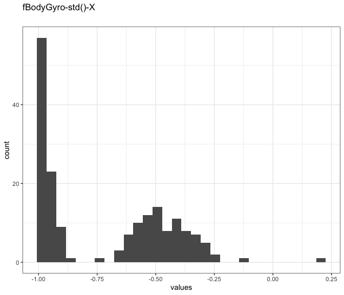

Distribution of values for fBodyGyro-std()-X

0 missing values.

#### Summary statistics

| name | data_type | n_missing | complete_rate | min | median | max | mean | sd | hist | label |
| --- | --- | --- | --- | --- | --- | --- | --- | --- | --- | --- |
| fBodyGyro-std()-X | numeric | 0 | 1 | -0.99 | -0.81 | 0.2 | -0.7110357 | 0.272789 | ▇▂▅▁▁ | NA |

### fBodyGyro-std()-Y

#### Distribution

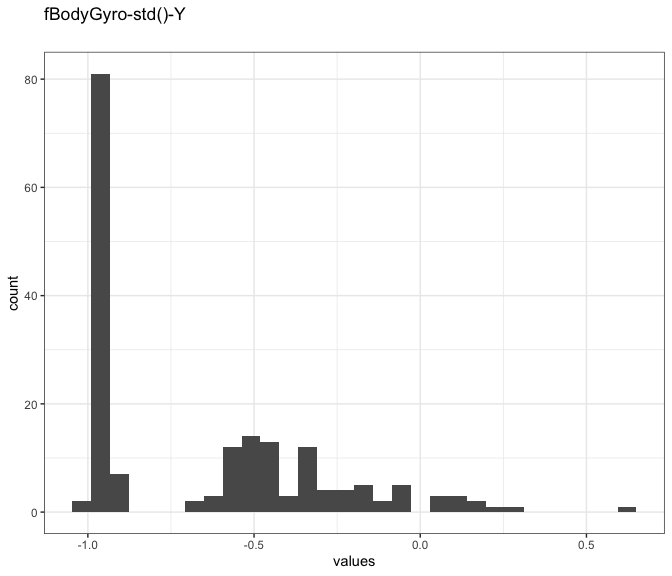

Distribution of values for fBodyGyro-std()-Y

0 missing values.

#### Summary statistics

| name | data_type | n_missing | complete_rate | min | median | max | mean | sd | hist | label |
| --- | --- | --- | --- | --- | --- | --- | --- | --- | --- | --- |
| fBodyGyro-std()-Y | numeric | 0 | 1 | -0.99 | -0.8 | 0.65 | -0.6454334 | 0.3634445 | ▇▅▂▁▁ | NA |

### fBodyGyro-std()-Z

#### Distribution

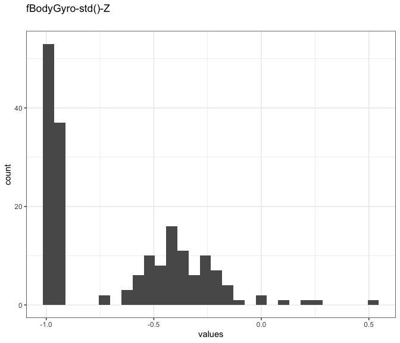

Distribution of values for fBodyGyro-std()-Z

0 missing values.

#### Summary statistics

| name | data_type | n_missing | complete_rate | min | median | max | mean | sd | hist | label |
| --- | --- | --- | --- | --- | --- | --- | --- | --- | --- | --- |
| fBodyGyro-std()-Z | numeric | 0 | 1 | -0.99 | -0.82 | 0.52 | -0.6577466 | 0.3362014 | ▇▃▃▁▁ | NA |

### fBodyGyro-meanFreq()-X

#### Distribution

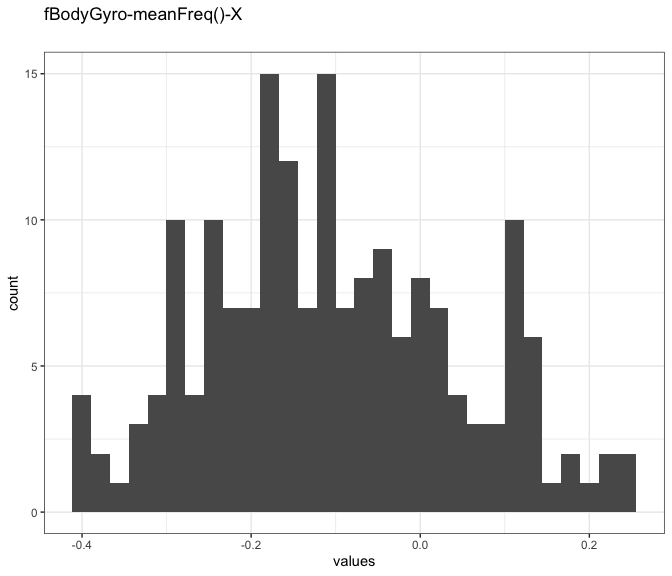

Distribution of values for fBodyGyro-meanFreq()-X

0 missing values.

#### Summary statistics

| name | data_type | n_missing | complete_rate | min | median | max | mean | sd | hist | label |
| --- | --- | --- | --- | --- | --- | --- | --- | --- | --- | --- |
| fBodyGyro-meanFreq()-X | numeric | 0 | 1 | -0.4 | -0.12 | 0.25 | -0.104551 | 0.1480975 | ▃▇▇▅▂ | NA |

### fBodyGyro-meanFreq()-Y

#### Distribution

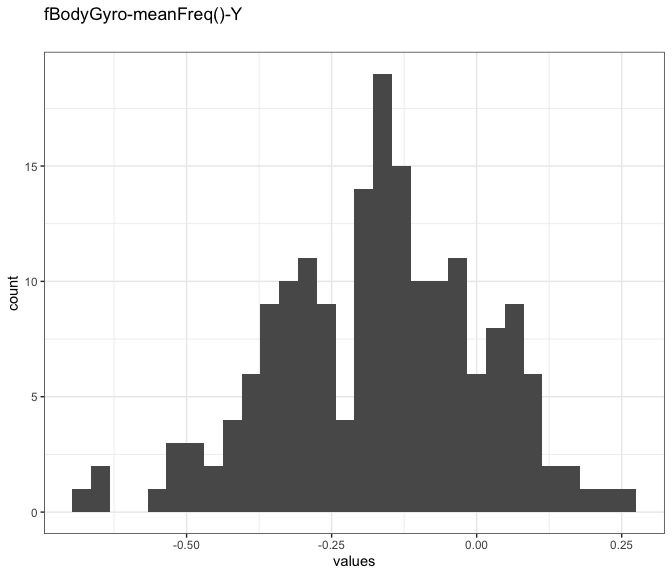

Distribution of values for fBodyGyro-meanFreq()-Y

0 missing values.

#### Summary statistics

| name | data_type | n_missing | complete_rate | min | median | max | mean | sd | hist | label |
| --- | --- | --- | --- | --- | --- | --- | --- | --- | --- | --- |
| fBodyGyro-meanFreq()-Y | numeric | 0 | 1 | -0.67 | -0.16 | 0.27 | -0.1674075 | 0.1788011 | ▁▅▇▆▂ | NA |

### fBodyGyro-meanFreq()-Z

#### Distribution

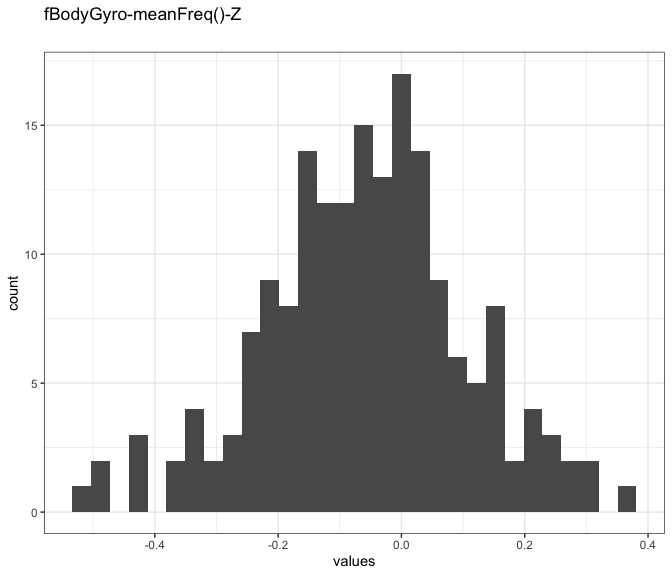

Distribution of values for fBodyGyro-meanFreq()-Z

0 missing values.

#### Summary statistics

| name | data_type | n_missing | complete_rate | min | median | max | mean | sd | hist | label |
| --- | --- | --- | --- | --- | --- | --- | --- | --- | --- | --- |
| fBodyGyro-meanFreq()-Z | numeric | 0 | 1 | -0.51 | -0.051 | 0.38 | -0.0571809 | 0.1652298 | ▁▃▇▃▁ | NA |

### fBodyAccMag-mean()

#### Distribution

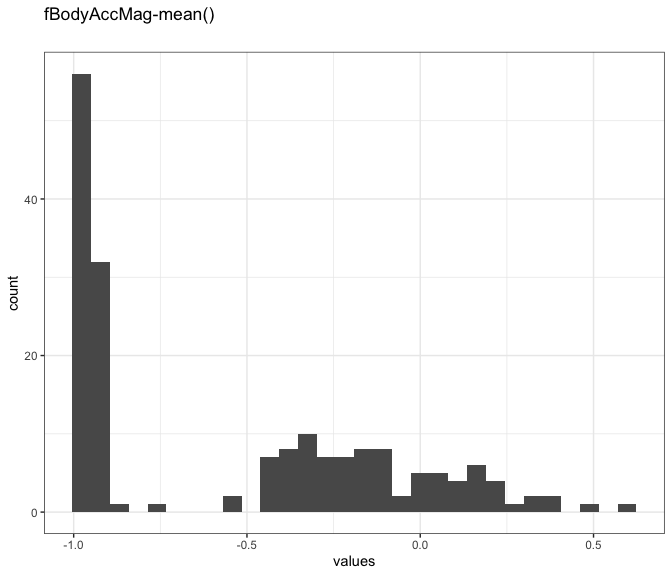

Distribution of values for fBodyAccMag-mean()

0 missing values.

#### Summary statistics

| name | data_type | n_missing | complete_rate | min | median | max | mean | sd | hist | label |
| --- | --- | --- | --- | --- | --- | --- | --- | --- | --- | --- |
| fBodyAccMag-mean() | numeric | 0 | 1 | -0.99 | -0.67 | 0.59 | -0.5365167 | 0.4516451 | ▇▂▃▂▁ | NA |

### fBodyAccMag-std()

#### Distribution

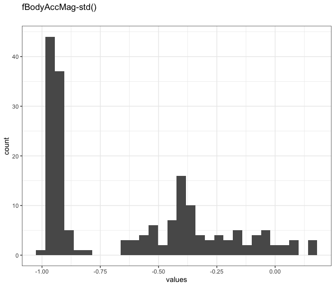

Distribution of values for fBodyAccMag-std()

0 missing values.

#### Summary statistics

| name | data_type | n_missing | complete_rate | min | median | max | mean | sd | hist | label |
| --- | --- | --- | --- | --- | --- | --- | --- | --- | --- | --- |
| fBodyAccMag-std() | numeric | 0 | 1 | -0.99 | -0.65 | 0.18 | -0.6209633 | 0.3529148 | ▇▁▃▂▁ | NA |

### fBodyAccMag-meanFreq()

#### Distribution

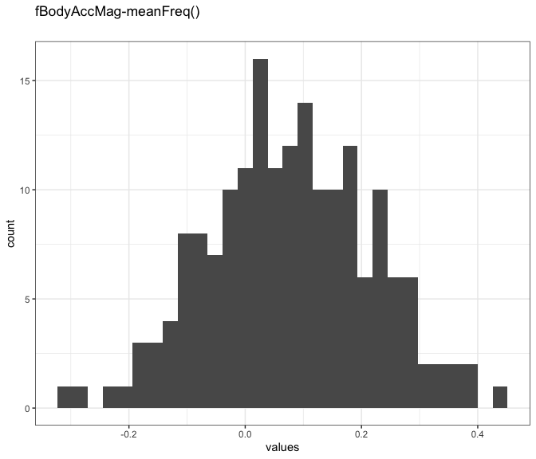

Distribution of values for fBodyAccMag-meanFreq()

0 missing values.

#### Summary statistics

| name | data_type | n_missing | complete_rate | min | median | max | mean | sd | hist | label |
| --- | --- | --- | --- | --- | --- | --- | --- | --- | --- | --- |
| fBodyAccMag-meanFreq() | numeric | 0 | 1 | -0.31 | 0.081 | 0.44 | 0.0761282 | 0.1404479 | ▁▅▇▅▁ | NA |

### fBodyBodyAccJerkMag-mean()

#### Distribution

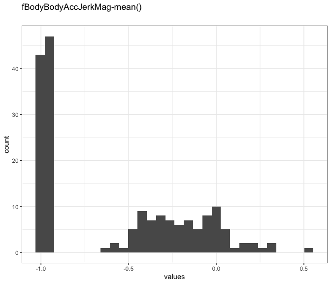

Distribution of values for fBodyBodyAccJerkMag-mean()

0 missing values.

#### Summary statistics

| name | data_type | n_missing | complete_rate | min | median | max | mean | sd | hist | label |
| --- | --- | --- | --- | --- | --- | --- | --- | --- | --- | --- |
| fBodyBodyAccJerkMag-mean() | numeric | 0 | 1 | -0.99 | -0.79 | 0.54 | -0.5756175 | 0.4312321 | ▇▂▃▂▁ | NA |

### fBodyBodyAccJerkMag-std()

#### Distribution

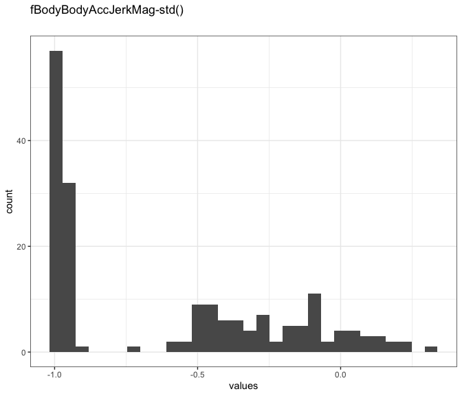

Distribution of values for fBodyBodyAccJerkMag-std()

0 missing values.

#### Summary statistics

| name | data_type | n_missing | complete_rate | min | median | max | mean | sd | hist | label |
| --- | --- | --- | --- | --- | --- | --- | --- | --- | --- | --- |
| fBodyBodyAccJerkMag-std() | numeric | 0 | 1 | -0.99 | -0.81 | 0.32 | -0.5991609 | 0.4086668 | ▇▁▃▂▁ | NA |

### fBodyBodyAccJerkMag-meanFreq()

#### Distribution

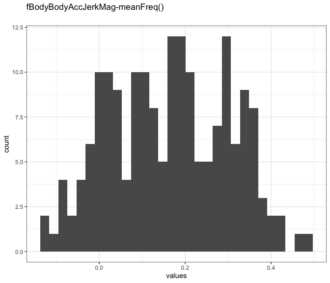

Distribution of values for fBodyBodyAccJerkMag-meanFreq()

0 missing values.

#### Summary statistics

| name | data_type | n_missing | complete_rate | min | median | max | mean | sd | hist | label |
| --- | --- | --- | --- | --- | --- | --- | --- | --- | --- | --- |
| fBodyBodyAccJerkMag-meanFreq() | numeric | 0 | 1 | -0.13 | 0.17 | 0.49 | 0.1625459 | 0.13783 | ▃▇▇▇▂ | NA |

### fBodyBodyGyroMag-mean()

#### Distribution

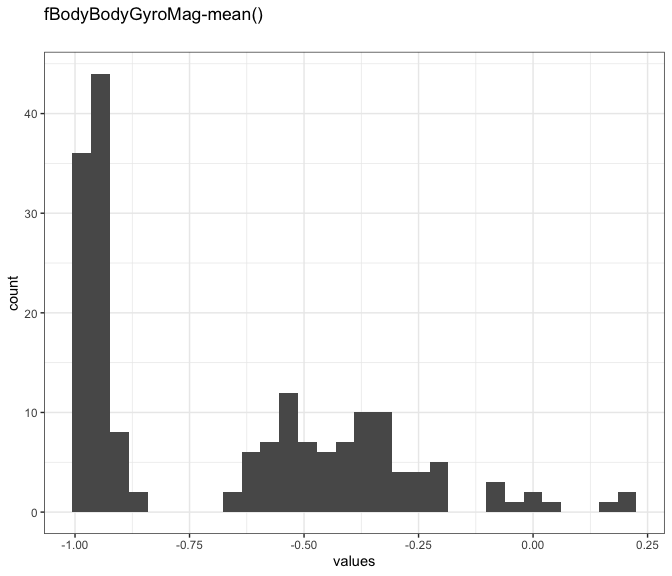

Distribution of values for fBodyBodyGyroMag-mean()

0 missing values.

#### Summary statistics

| name | data_type | n_missing | complete_rate | min | median | max | mean | sd | hist | label |
| --- | --- | --- | --- | --- | --- | --- | --- | --- | --- | --- |
| fBodyBodyGyroMag-mean() | numeric | 0 | 1 | -0.99 | -0.77 | 0.2 | -0.6670991 | 0.3181183 | ▇▂▃▁▁ | NA |

### fBodyBodyGyroMag-std()

#### Distribution

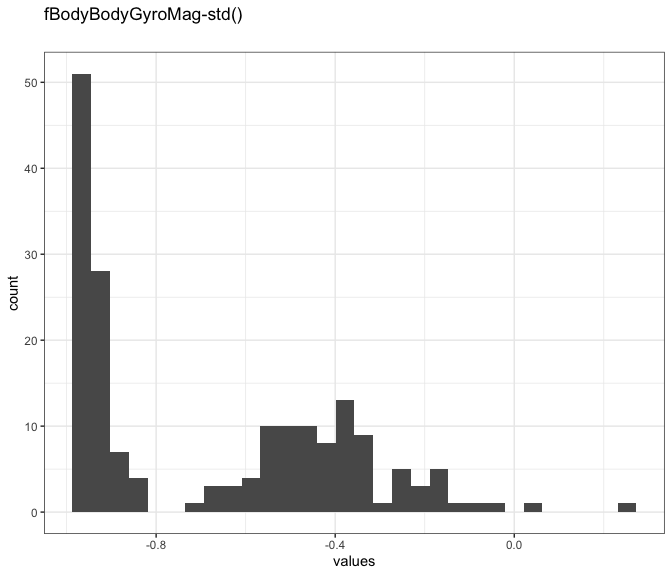

Distribution of values for fBodyBodyGyroMag-std()

0 missing values.

#### Summary statistics

| name | data_type | n_missing | complete_rate | min | median | max | mean | sd | hist | label |
| --- | --- | --- | --- | --- | --- | --- | --- | --- | --- | --- |
| fBodyBodyGyroMag-std() | numeric | 0 | 1 | -0.98 | -0.77 | 0.24 | -0.6723223 | 0.2931842 | ▇▂▅▁▁ | NA |

### fBodyBodyGyroMag-meanFreq()

#### Distribution

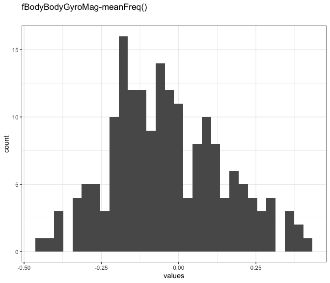

Distribution of values for fBodyBodyGyroMag-meanFreq()

0 missing values.

#### Summary statistics

| name | data_type | n_missing | complete_rate | min | median | max | mean | sd | hist | label |
| --- | --- | --- | --- | --- | --- | --- | --- | --- | --- | --- |
| fBodyBodyGyroMag-meanFreq() | numeric | 0 | 1 | -0.46 | -0.054 | 0.41 | -0.0360322 | 0.1807351 | ▂▇▇▅▂ | NA |

### fBodyBodyGyroJerkMag-mean()

#### Distribution

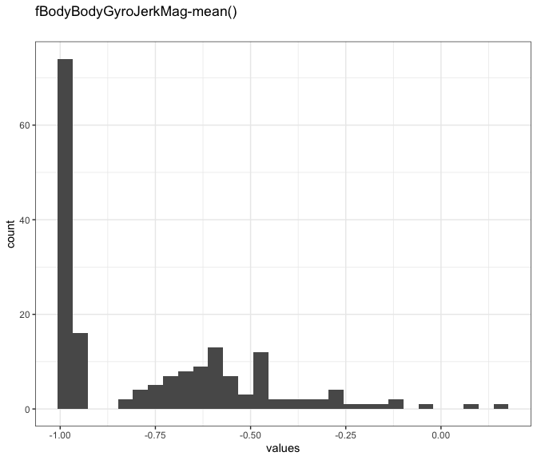

Distribution of values for fBodyBodyGyroJerkMag-mean()

0 missing values.

#### Summary statistics

| name | data_type | n_missing | complete_rate | min | median | max | mean | sd | hist | label |
| --- | --- | --- | --- | --- | --- | --- | --- | --- | --- | --- |
| fBodyBodyGyroJerkMag-mean() | numeric | 0 | 1 | -1 | -0.88 | 0.15 | -0.7563853 | 0.2628722 | ▇▅▂▁▁ | NA |

### fBodyBodyGyroJerkMag-std()

#### Distribution

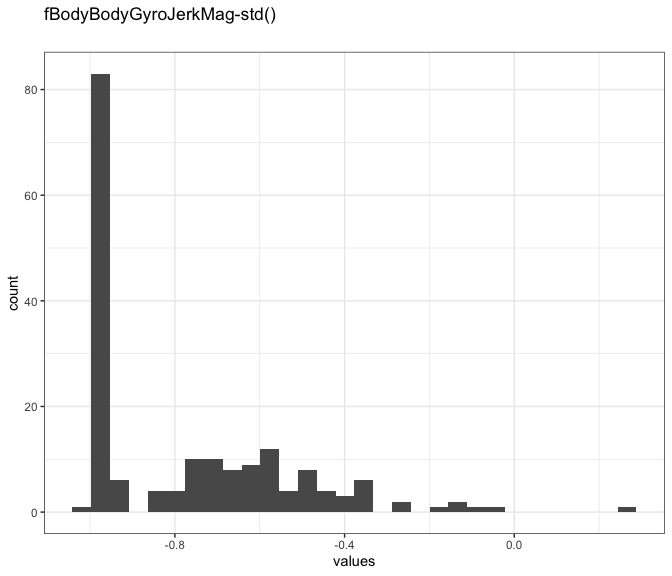

Distribution of values for fBodyBodyGyroJerkMag-std()

0 missing values.

#### Summary statistics

| name | data_type | n_missing | complete_rate | min | median | max | mean | sd | hist | label |
| --- | --- | --- | --- | --- | --- | --- | --- | --- | --- | --- |
| fBodyBodyGyroJerkMag-std() | numeric | 0 | 1 | -1 | -0.89 | 0.29 | -0.7715171 | 0.2504248 | ▇▃▁▁▁ | NA |

### fBodyBodyGyroJerkMag-meanFreq()

#### Distribution

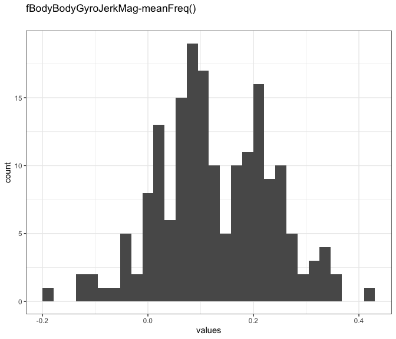

Distribution of values for fBodyBodyGyroJerkMag-meanFreq()

0 missing values.

#### Summary statistics

| name | data_type | n_missing | complete_rate | min | median | max | mean | sd | hist | label |
| --- | --- | --- | --- | --- | --- | --- | --- | --- | --- | --- |
| fBodyBodyGyroJerkMag-meanFreq() | numeric | 0 | 1 | -0.18 | 0.11 | 0.43 | 0.1259225 | 0.1083232 | ▁▅▇▆▁ | NA |